# Probability and Statistics

# Lab Assignment 1: Naive Bayes Classifier

### *Andrii Yaroshevych, Dmytro Vasylkiv, Vitalii Petrychko*

## Introduction

During the past three weeks, you learned a couple of essential notions and theorems, and one of the most important among them is the *Bayes theorem*.

One of its applications is **Naive Bayes classifier**, which is a probabilistic classifier whose aim is to determine which class some observation probably belongs to by using the Bayes formula:
$$\mathsf{P}(\mathrm{class}\mid
\mathrm{observation})=\frac{\mathsf{P}(\mathrm{observation}\mid\mathrm{class})\mathsf{P}(\mathrm{class})}{\mathsf{P}(\mathrm{observation})}$$

Under the strong independence assumption, one can calculate $\mathsf{P}(\mathrm{observation} \mid \mathrm{class})$ as
$$\mathsf{P}(\mathrm{observation}) =
\prod_{i=1}^{n} \mathsf{P}(\mathrm{feature}_i), \qquad
\mathsf{P}(\mathrm{observation} \mid \mathrm{class}) = \prod_{i=1}^{n}
\mathsf{P}(\mathrm{feature}_i \mid \mathrm{class}),$$
where $n$ is the total number of features describing a given observation. Thus, $\mathsf{P}(\mathrm{class}|\mathrm{observation})$ now can be calculated as

$$\mathsf{P}(\mathrm{class} \mid
\mathrm{\mathrm{observation}}) = \mathsf{P}(\mathrm{class})\times
\prod_{i=1}^{n}\frac{\mathsf{P}(\mathrm{feature}_i\mid
\mathrm{class})}{\mathsf{P}(\mathrm{feature}_i)}\tag{1}$$

All the terms on the right-hand side can be estimated from the data as respective relative frequencies;  
see [this site](https://monkeylearn.com/blog/practical-explanation-naive-bayes-classifier/) for more detailed explanations.

## Data description

- **2 - fake news** This data set contains data of American news: a headline and an abstract of the article. Each piece of news is classified as fake or credible. The task is to classify the news from test.csv as credible or fake.

```r
library(tidytext)
library(readr)
library(dplyr)
library(ggplot2)
```

## Instructions

- The first step is data pre-processing, which includes removing punctuation marks and stop words
- Represent each message as a bag-of-words
- Using the training set, calculate all the conditional probabilities in formula (1)
- Use those to predict classes for messages in the test set
- Evaluate effectiveness of the classifier by calculating the corresponding metrics
- Shortly summarize your work
- Do not forget to submit both the (compiled) Rmd source file and the .html output

### Data pre-processing

- Read the *.csv* data files.
- Сlear your data from punctuation or other unneeded symbols.
- Clear you data from stop words. You don’t want words as is, and, or etc. to affect your probabilities distributions, so it is a wise decision to get rid of them. Find list of stop words in the cms under the lab task.
- Represent each test message as its bag-of-words.

```r
test_path <- "data/2-fake_news/test.csv"
train_path <- "data/2-fake_news/train.csv"

train <- read.csv(file = train_path, stringsAsFactors = FALSE)
test <- read.csv(file = test_path, stringsAsFactors = FALSE)
```

```r
stop_words_file <- read_file("stop_words.txt")

stop_words <- strsplit(stop_words_file, split='\n')
stop_words <- stop_words[[1]]
```

```r
tidy_text <- unnest_tokens(train, 'splitted', 'Body', token="words", to_lower = TRUE) %>%
             filter(!splitted %in% stop_words)
```

### Data visualization

Top words in the dataset

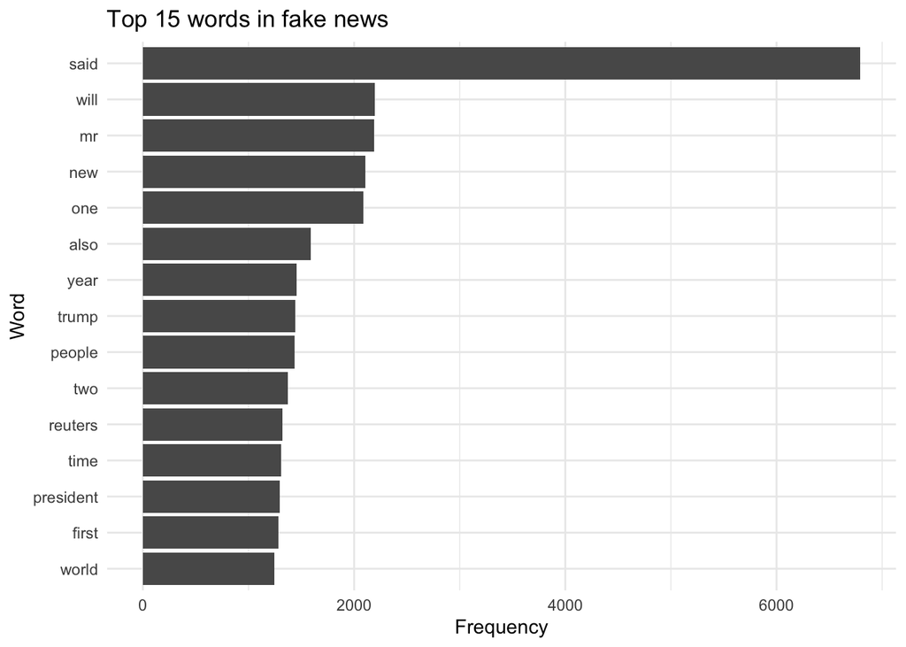

```r
fake_news <- tidy_text %>%
             filter(Label == "fake") %>%
             count(splitted, sort=TRUE) %>%
             top_n(15)

credible_news <- tidy_text %>%
                 filter(Label == "credible") %>%
                 count(splitted, sort=TRUE) %>%
                 top_n(15)

ggplot(fake_news, aes(x = n, y = reorder(splitted, n))) +
    geom_col() +
    labs(x = "Frequency", y = "Word", title = "Top 15 words in fake news") +
    theme_minimal()
```

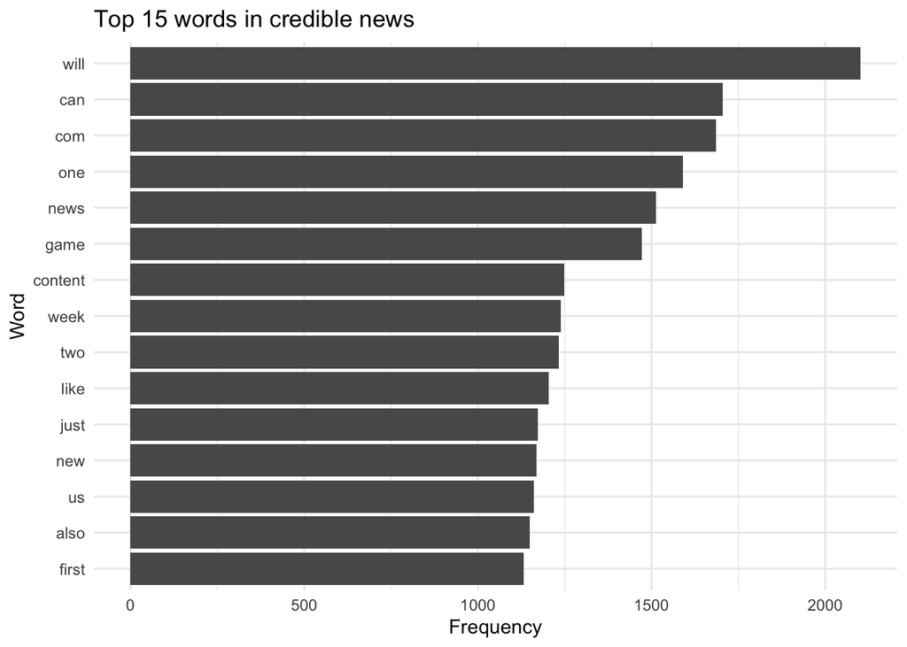

```r
ggplot(credible_news, aes(x = n, y = reorder(splitted, n))) +
    geom_col() +
    labs(x = "Frequency", y = "Word", title = "Top 15 words in credible news") +
    theme_minimal()
```

Chart representation of classes distribution

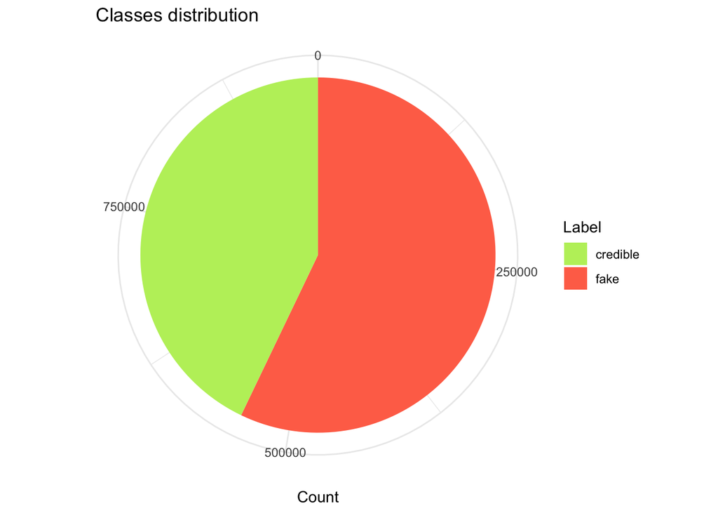

```r
pie_chart <- tidy_text %>%
             count(Label, sort=TRUE)

ggplot(pie_chart, aes(x = "", y = n, fill = Label)) +
    geom_bar(width = 1, stat = "identity") +
    coord_polar("y", start = 0) +
    labs(x = "", y = "Count", title = "Classes distribution") +
    scale_fill_manual(aesthetics = "fill", values = c("darkolivegreen2", "coral1")) +
    theme_minimal()
```

## Classifier implementation

```r
naiveBayes <- setRefClass("naiveBayes",

       fields = list(
         data = "data.frame",
         fake_data = "data.frame",
         credible_data = "data.frame",
         number_of_fake_news = "numeric",
         number_of_credible_news = "numeric",
         fake_news_prob = "numeric",
         credible_news_prob = "numeric",
         fake_news_word_count = "numeric",
         credible_news_word_count = "numeric",
         total_word_count = "numeric"
       ),

       methods = list(
                    fit = function(data)
                    {
                        data <<- data
                        fake_data <<- data %>% filter(Label=="fake") %>% count(splitted, sort=TRUE)
                        credible_data <<- data %>% filter(Label=="credible") %>% count(splitted, sort=TRUE)

                        number_of_fake_news <<- nrow(train %>% filter(Label=="fake"))
                        number_of_credible_news <<- nrow(train %>% filter(Label=="credible"))

                        fake_news_prob <<- number_of_fake_news/(number_of_fake_news + number_of_credible_news)
                        credible_news_prob <<- number_of_credible_news/(number_of_fake_news + number_of_credible_news)

                        fake_news_word_count <<- sum(fake_data$n)
                        credible_news_word_count <<- sum(credible_data$n)

                        total_word_count <<- nrow(data %>% distinct(splitted))
                    },

                    predict = function(message)
                    {
                        message <- tolower(message)
                        entries <- strsplit(message, split=" ")[[1]]
                        entries <- entries[!grepl("[[:punct:]]", entries)]
                        entries <- entries[!(entries %in% stop_words)]

                        result <- 1

                        for (word in entries) {
                            number_of_entries_fake <- ifelse(
                              word %in% fake_data$splitted,
                              fake_data %>% filter(splitted==word) %>% pull(n), 0)

                            fake_word_conditional_prob <- (number_of_entries_fake + 1)/
                              (fake_news_word_count + total_word_count)

                            number_of_entries_credible <- ifelse(
                              word %in% credible_data$splitted,
                              credible_data %>% filter(splitted==word) %>% pull(n), 0)

                            credible_word_conditional_prob <- (number_of_entries_credible + 1)/
                              (credible_news_word_count + total_word_count)

                            result <- result * (fake_word_conditional_prob/credible_word_conditional_prob)
                        }

                        result <- result * (fake_news_prob/credible_news_prob)

                        if (result > 1) {
                            return("fake")
                        } else {
                            return("credible")
                        }
                    },

                    score = function(test)
                    {
                         result <- data.frame(test)
                         result$PredictedLabel <- apply(result["Body"], MARGIN=1, .self$predict)

                         write.csv(result,'result.csv')
                         correct_values <- nrow(result %>% filter(result$Label == result$PredictedLabel))

                         return(correct_values/nrow(result))
                    }
))

model <- naiveBayes()
model$fit(tidy_text)
```

## Effectiveness of classifier

All calculations can be done using the `result.csv` file. The accuracy of the classifier is 93%.

Here we will use the actual and predicted labels to calculate all the metrics.

```r
result <- read.csv("result.csv", stringsAsFactors = TRUE)
```

```r
confusion_matrix <- table(result$Label, result$PredictedLabel, dnn = c("Actual", "Predicted"))
```

```r
accuracy <- sum(diag(confusion_matrix))/sum(confusion_matrix)
print(accuracy)
```

```
## [1] 0.9289277
```

```r
precision <- confusion_matrix[1,1]/sum(confusion_matrix[,1])
print(precision)
```

```
## [1] 0.9731051
```

```r
recall <- confusion_matrix[1,1]/sum(confusion_matrix[1,])
print(recall)
```

```
## [1] 0.8963964
```

```r
f1_score <- 2 * (precision * recall)/(precision + recall)
print(f1_score)
```

```
## [1] 0.933177
```

Or, we can use the `caret` package to calculate all the metrics.

```r
library(caret)
confusionMatrix(result$Label, result$PredictedLabel)
```

```
## Confusion Matrix and Statistics
##
##           Reference
## Prediction credible fake
##   credible      398   46
##   fake           11  347
##
##                Accuracy : 0.9289
##                  95% CI : (0.9089, 0.9457)
##     No Information Rate : 0.51
##     P-Value [Acc > NIR] : < 2.2e-16
##
##                   Kappa : 0.8576
##
##  Mcnemar's Test P-Value : 6.687e-06
##
##             Sensitivity : 0.9731
##             Specificity : 0.8830
##          Pos Pred Value : 0.8964
##          Neg Pred Value : 0.9693
##              Prevalence : 0.5100
##          Detection Rate : 0.4963
##    Detection Prevalence : 0.5536
##       Balanced Accuracy : 0.9280
##
##        'Positive' Class : credible
##
```

Visualization of the confusion matrix:

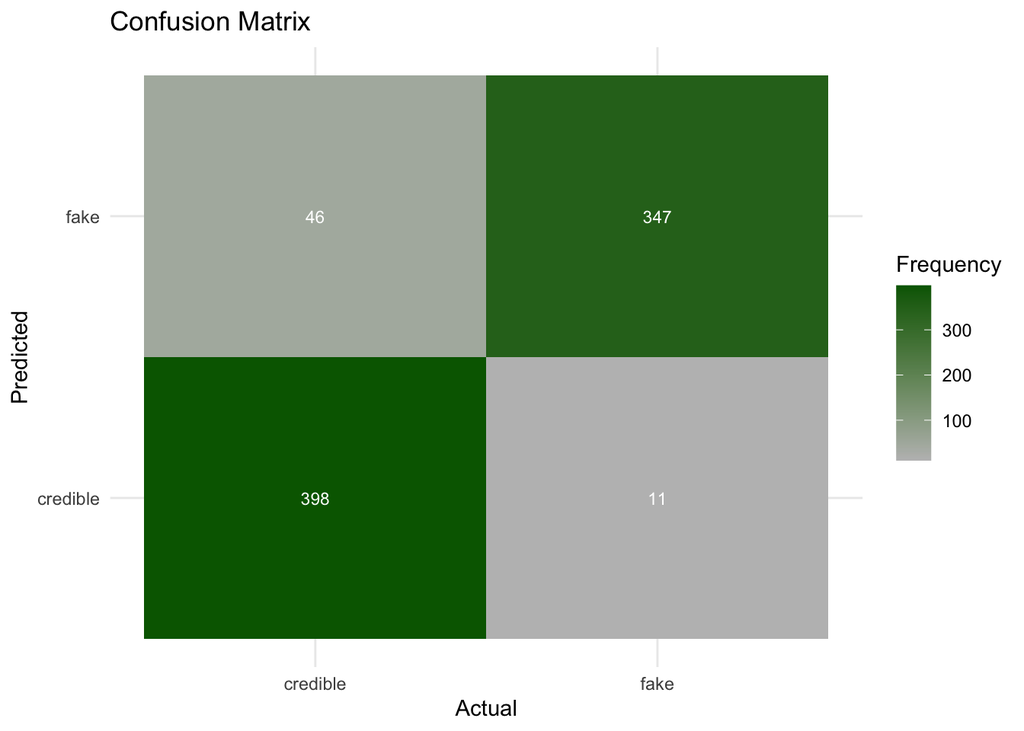

```r
library(ggplot2)

confusion_data <- as.data.frame(confusion_matrix)

ggplot(confusion_data, aes(x = Actual, y = Predicted, fill = Freq)) +
    geom_tile() +
    geom_text(aes(label = Freq), size = 3, color = "white") +
    labs(x = "Actual", y = "Predicted", title = "Confusion Matrix") +
    scale_fill_gradient(low = "grey", high = "darkgreen", name = "Frequency") +
    theme_minimal()
```

## Algorithm

#### Steps taken to perform the task :

- Analyze the dataset, process it to turn into a bag-of-words
- Use Bayes’ formula to try to predict the class of a message
- Calculate the probability for the bag-of-word to be in fake class
- Calculate the probability for the bag-of-word to be in credible class
- Compare them
- Compute the success of the predictions
- Calculate the metrics to evaluate the effectiveness of the classifier
- Form the confusion matrix to represent the effectiveness of the method
- Form the diagram and visualize the statistics

## Conclusion

#### Metrics:

**Accuracy : 0.9289**

**Precision : 0.97**

**Recall : 0.90**

**F1 score : 0.93**

#### Pros of using Naive Bayes approach :

- Simple and easy to implement. Naive Bayes uses basic probability formulas and concepts and clear algorithm.
- Comparatively fast by the assumption that the features are independent. That is one of the reasons why Naive Distribution is used on big datasets.

#### Cons of using Naive Bayes approach :

- Does not work for non-independent features. The count of datasets having completely independent features is reaching zero, so we can use Naive Bayes only when speed is more praised than the accuracy

In the dataset given, we actually assumed that there was no correlation between the word frequency and our method still had good results. However, it could be a good practise e.g. to consider the dependencies of the word appearance. Still, Naive Bayes has pretty good classification accuracy.